# LISTA DE EXERCICIO 05

# Variáveis aleatórias contínuas: alguns Modelos Probabilísticos

Aluno: MARCEL DANTAS DE QUINTELA

## Questão 1

Para cada cliente que entra na fila do caixa de uma loja de roupas, temos que:

- O tempo de espera na fila segue uma distribuição de probabilidade exponencial com média de 5 minutos;
- O tempo de atendimento segue uma distribuiçãoo de probabilidade exponencial com média de 5 minutos;
- Esses dois tempos são v.a.’s independentes.

Para a variável **“tempo total do cliente no caixa”** - incluindo a espera na fila e o atendimento –, responda:

### Respostas - Questão 1

> **Letra** **a.** Que modelo probabilístico seria adequado para esta variável? Justifique sua resposta.

> **Letra** **b.** Calcule a probabilidade de que esse tempo ultrapasse um limite aceitável de 10 minutos. Dica: qual a distribuição de soma v.a.’s com distribuição Exponencial?

> Sejam:
> - X v.a. tempo de espera na fila do caixa de uma loja de roupas, cuja distribuição segue $X \sim Exp(1/5)$;
> - Y v.a. tempo de espera de atendimento de uma loja de roupas, cuja distribuição segue $Y \sim Exp(1/5)$; e

> Sendo X e Y v.a. independentes, temos:
> - Z v.a. o tempo total de espera $ Z= (X+Y) $, onde $Z \sim Gama(n=2,\lambda= 1/5)$

>   $P(Z>10)=?$

```r
 pgamma(10,shape=2,rate=1/5,lower.tail=FALSE)
```

```
## [1] 0.4060058
```

## Questão 2

Para que um satélite possa ser corretamente controlado, a distância entre ele e o alvo tem de ser menor que 6, 6 pés. Neste caso considera-se que houve um sucesso. Admitindo que o alvo está localizado na origem de um determinado eixo, a posição do satélite (em pés) ao longo desse eixo se comporta segundo uma distribuição Normal com média zero e desvio padrão igual a 4. Nessas condições:

1. Calcule a probabilidade de falha no controle do satélite.
2. Quando 5 satélites são lançados, qual a probabilidade de se obter exatamente 3 sucessos?

### Respostas - Questão 2

> Letra **a.** Calcule a probabilidade de falha no controle do satélite.

Seja **X** v.a. representa a distância em pés entre um satélite e um determinado eixo, cuja distribuição segue $X \sim N(\mu=0,\sigma^2=16)$

Considerando que estamos trabalhando com distâncias é conveniente represenrtarmos as probabilidades da v.a. como o módulo da v.a, logo:

$$P(\lvert X\lvert >6,6)=P(\lvert Z\lvert>{6,6\over 4})$$

```r
# Problabilidade a partir do modelo
(p <- pnorm(6.6,mean=0,sd=sqrt(16),lower.tail = FALSE)*2)
```

```
## [1] 0.09894294
```

```r
# Integrate normal padrão
p1 <- integrate(function(x) {1/sqrt(2*pi)*exp(-x^2/2)},lower=-6.6/4,upper=6.6/4)
1- p1$value
```

```
## [1] 0.09894294
```

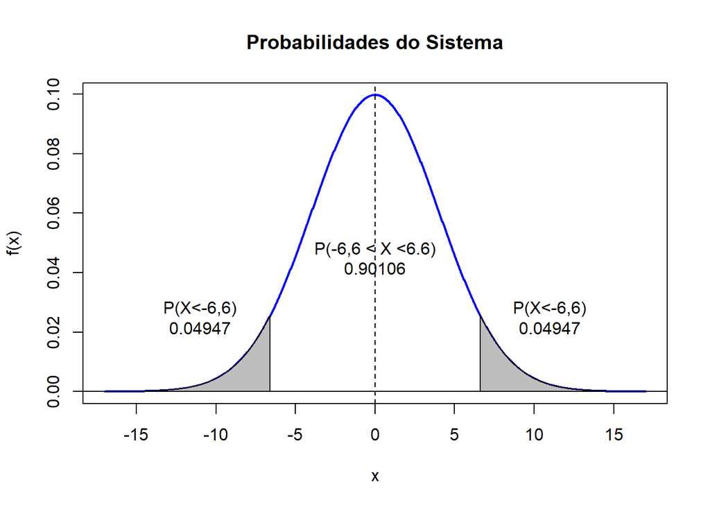

```r
# ILUSTRANDO
x=seq(-17,17,length=1000)
y=dnorm(x, mean=0,sd=sqrt(16))
x1=seq(-16,-6.6,length=500);x2=seq(6.6,16,length=500)
y1=dnorm(x1, mean=0, sd=sqrt(16));y2=dnorm(x2, mean=0, sd=sqrt(16))

plot(x,y,xlab="x",ylab="f(x)",type="l", lwd=2, col="blue",
     main="Probabilidades do Sistema")
polygon(c(-16,x1,-6.6),c(0,y1,0),col="gray")
polygon(c(6.6,x2,16),c(0,y2,0),col="gray")
text(0, 0.045,paste0("P(-6,6 < X <6.6)\n", round(1-p,5)))
text(-11, 0.025,paste0("P(X<-6,6)\n",round(p/2,5)))
text( 11, 0.025,paste0("P(X<-6,6)\n",round(p/2,5)))
abline(h=0)
abline(v=0,lty=2)
```

> Letra **b.** Quando 5 satélites são lançados, qual a probabilidade de se obter exatamente 3 sucessos?

Seja **Z** v.a. representa o nº de sucessos em 5 lançamentos de satélites, onde $Z \sim Binomial(n=5,p^*=0.9)$ , $^*P(sucesso)=1 - [P(\lvert X\lvert >6,6)]\cong 0.90$

$$P(Z=3)={5\choose 3} 0.9^3 (0.1)^2$$

```r
dbinom(3,5,0.9) # P(Z=3)
```

```
## [1] 0.0729
```

## Questão 3

Uma instituição de sáude, preocupada com a má alimentação das crianças, deseja realizar uma pesquisa para investigar o número de crianças obesas numa determinada região, através do índice de massa corpórea (IMC). Sabe-se que o IMC das crianças nesta região segue uma distribuição Normal com média 21.5 e desvio padrão de 2, e indivíduos com IMC superior a 23 são considerados obesos.

1. Calcule a probabilidade de uma criança apresentar o IMC entre 20.5 e 22.
2. Qual a probabilidade de uma criança ser considerada obesa?
3. Em uma amostra aleatória de 20 crianças, qual a probabilidade de que pelo menos 15 dessas crianças sejam obesas?
4. Qual o IMC a partir do qual estão as 10% das crianças com menor IMC na região?

### Respostas - Questão 3

Seja **X** v.a. representa o IMC de crianças, cuja distribuição segue $X \sim N(\mu=21.5,\sigma^2=2^2)$

> **Letra a.** Calcule a probabilidade de uma criança apresentar o IMC entre 20.5 e 22.

> $P(20.5<X<22)=?$

```r
pnorm(22,mean=21.5,sd=2) - pnorm(20.5,mean=21.5,sd=2)
```

```
## [1] 0.2901688
```

> **Letra b.** Qual a probabilidade de uma criança ser considerada obesa?

> $P(X>23)=?$

```r
pnorm(23,mean=21.5,sd=2, lower.tail = FALSE )
```

```
## [1] 0.2266274
```

```r
# 1- pnorm(23,mean=21.5,sd=2)
```

> **Letra c.** Em uma amostra aleatória de 20 crianças, qual a probabilidade de que pelo menos 15 dessas crianças sejam obesas?

> Y v.a. que representa o nº de crianças obesas, cujo distribuição segue $Y \sim Binomial(20;P(X>23))$

> $P(Y\geq y)=\sum \limits_{y=15}^{20} {20\choose y} P(X>23)^y (1-P(X>23))^{20-y}$

```r
p<-pnorm(23,mean=21.5,sd=2, lower.tail = FALSE )
#P(Y>14)=P(Y>=15)
pbinom(14,20,p,lower.tail = FALSE)
```

```
## [1] 1.006368e-06
```

> **Letra d.** Qual o IMC a partir do qual estão as 10% das crianças com menor IMC na região?

> $P(X\leq x)=0.10$

```r
qnorm(0.1,mean=21.5,sd=2)
```

```
## [1] 18.9369
```

## Questão 4

No R, digite os seguintes comandos:

> install.packages(“flexmix”)  
> require(flexmix)  
> data(“Nclus”)  
> Nclus = data.frame(Nclus)  
> View(Nclus)  
> hist(Nclus$X1)  
> hist(Nclus$X2)  
> plot(Nclus$X1,Nclus$X2) # caso fossemos usar uma regressão

Pede-se: interprete os gráficos que aparecem, informando que tipo de modelo poderia ser adequado para modelar a variável $X_1$ e $X_2$, justificando sua resposta.

```r
if (!require("flexmix")) install.packages("flexmix", dependencies = TRUE, INSTALL_opts = '--no-lock')
require(flexmix)
data("Nclus")
Nclus = data.frame(Nclus)
```

```r
#View(Nclus)
```

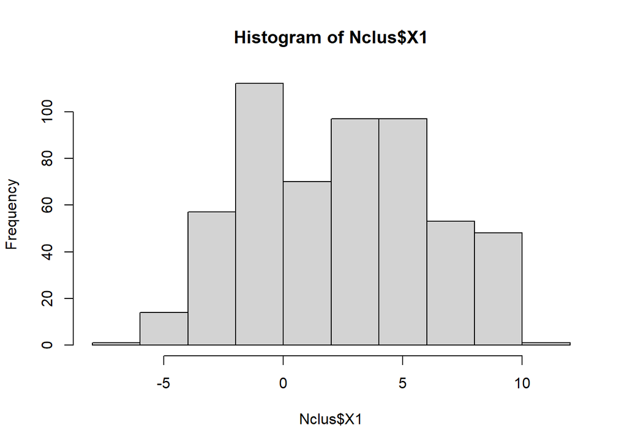

```r
hist(Nclus$X1)
```

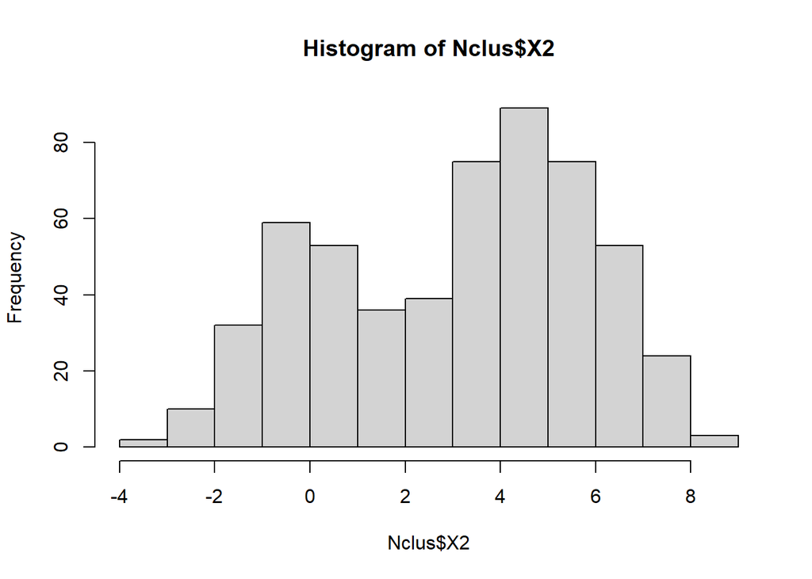

```r
hist(Nclus$X2)
```

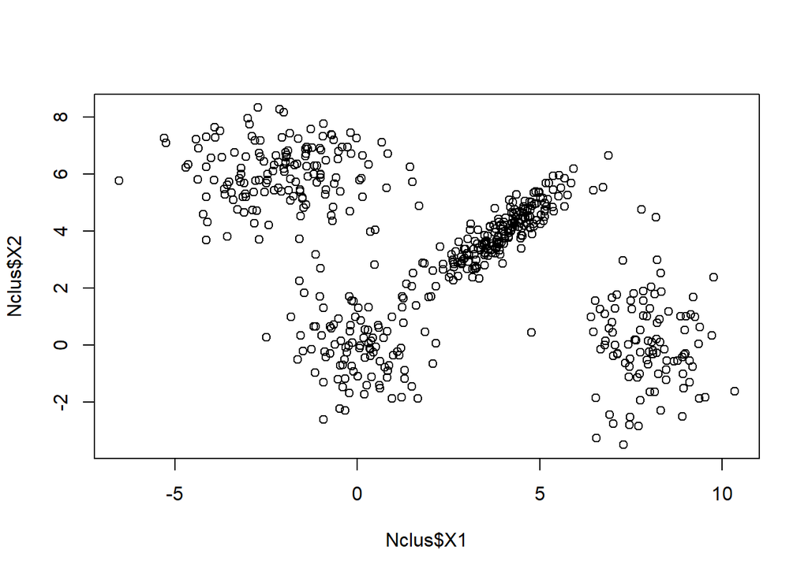

```r
plot(Nclus$X1,Nclus$X2) # caso fossemos usar uma regressão
```

### Respostas - Questão 4

A partir das análises gráficas as variáveis apresentadas não seria possível acirmar que alguama delas, mesmo preliminarmente, indicasse se assemelar a alguma distribuiçao de probabilidade definida. A aparente bimodalidade aparente pode ser um dos fatores da indefinição da distribuição de probabilidade, indicando ainda a possibilidade de mistura de amostras de poulações distintas, falhas na coleta ou mesmo indicando a necessidade de tranformações das variáveis originais.

## Questão 5

Há o interesse em analisar o número de pessoas que recorrem ao balcão de informações de um aeroporto ao longo de um dia. Um dos balcões funciona de 0h às 06h (ou seja, 25% do dia), enquanto o outro funciona no tempo restante. Sabe-se que, o número de usuários que recorrem ao balcão que fica aberto de 0 às 6h segue uma variável aleatória Poisson com média λ = 3 pessoas por hora, enquanto o número de usuários que recorrem ao balcão no horário restante segue um modelo Poisson com média de chegada λ = 10 pessoas por hora. Calcule a probabilidade de que entre 10 e 15 pessoas recorrerão ao balcão de informações em uma hora qualquer.

### Respostas - Questão 5

- **X:** nº de pessoas que recorren ao Balcão A (funciona das 0h às 06h), $X \sim Poisson(\lambda=3)$
- **Y**: nº de pessoas que recorrem ao Balcão B (funciona das 06h às 0h), $Y \sim Poisson(\lambda=10)$
- **Z**: número de pessoas que procuram informações em qualquer balcão em uma hora qualquer, $Z \sim Poisson(\lambda_x=3*6/24+\lambda_y=10*18/24)$

  $$P(10\le Z \le 15)=?$$

  ```r
  L<-3*6/24+10*18/24
  ppois(15,L)-ppois(9,L)
  ```

  ```
  ## [1] 0.304092
  ```

## Questão 6

Analisando o dado usado em aula de notas de alunos em provas de Matemática, Inglês e História, indique que modelo você usaria para modelar as notas transformadas em cada uma das provas (como consta no comando abaixo) e como você obteria de uma forma geral os parâmetros do modelo que se adequam ao dado. Justifique sua resposta. Para iniciar sua análise, digite os seguintes comandos no R:

> dado = read.csv(“Marks.csv”)  
> View(dado)  
> dado = dado/100 # transformando o dado para outra escala  
> hist(dado$Maths_Marks,freq=FALSE,bty=“n”,main=“Math”,xlab="“,ylab=”Densidade“)  
> hist(dado$English_Marks,freq=FALSE,bty=”n“,main=”Ing“,xlab=”“,ylab=”Densidade“)  
> hist(dado$History_Marks,freq=FALSE,bty=”n“,main=”Hist“,xlab=”“,ylab=”Densidade")

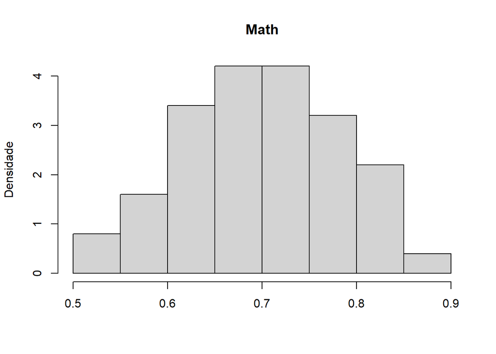

```r
dado = read.csv("Marks.csv")
#View(dado)
dado = dado/100 #transformando o dado para outra escala
hist(dado$Maths_Marks,freq=FALSE,bty="n",main="Math",xlab="",ylab="Densidade")
```

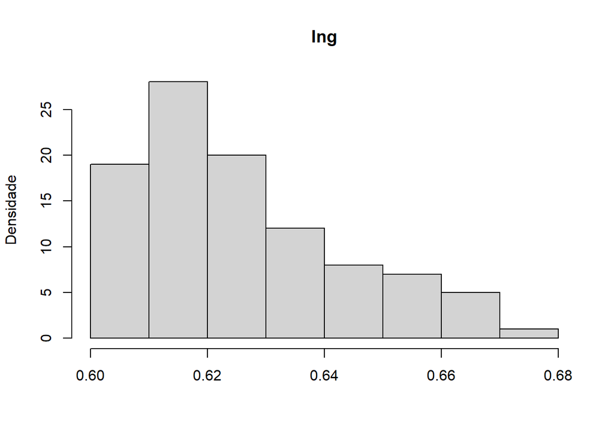

```r
hist(dado$English_Marks,freq=FALSE,bty="n",main="Ing",xlab="",ylab="Densidade")
```

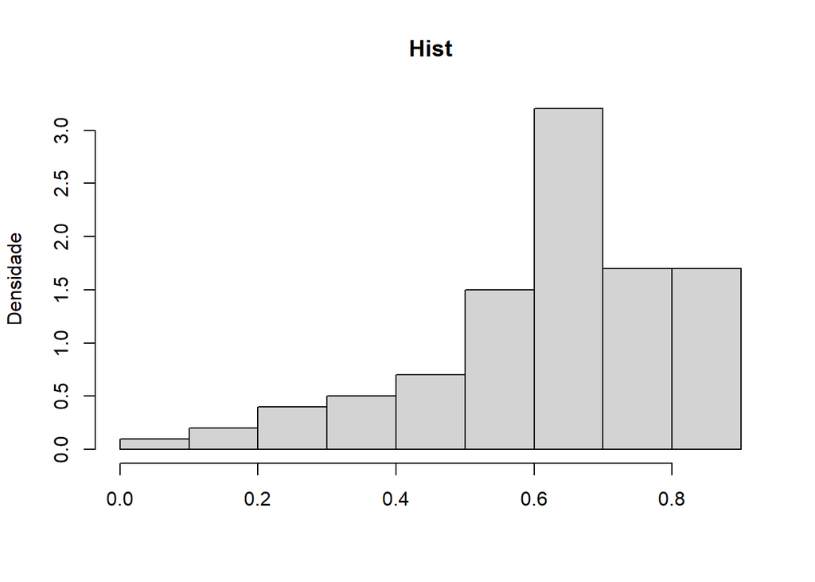

```r
hist(dado$History_Marks,freq=FALSE,bty="n",main="Hist",xlab="",ylab="Densidade")
```

### Respostas - Questão 6

Os dados da variável Math aparentam seguir uma distribuição simétrica centrada na média, apesar da necessidade de confirmação, esses dados se assemelham a uma distribuição normal. As demais variáveis apresentam assimetria e caudas mais densas se distanciando da distribuição normal. Contudo diante da natureza da tranformação dos dados originais em percentual o modelo uma Beta seria descrever todas as três variáveis.

## Questão 7

No dado diabetes do pacote faraway usado em aula, estamos interessados na variável hdl que representa o nível do colesterol HDL nos indivíduos. Digite os comandos abaixo no R, analise os gráficos e indique que modelo você usaria para esse dado, justificando sua resposta.

> require(faraway)  
> data(diabetes)  
> View(diabetes)  
> hist(diabetes$hdl,freq=FALSE)  
> curve(dnorm(x,mean(diabetes$hdl,na.rm=TRUE),sd(diabetes$hdl,na.rm=TRUE)), add=TRUE)  
> boxplot(diabetes$hdl)  
> qqnorm(diabetes$hdl)  
> qqline(diabetes$hdl)

```r
require(faraway)
```

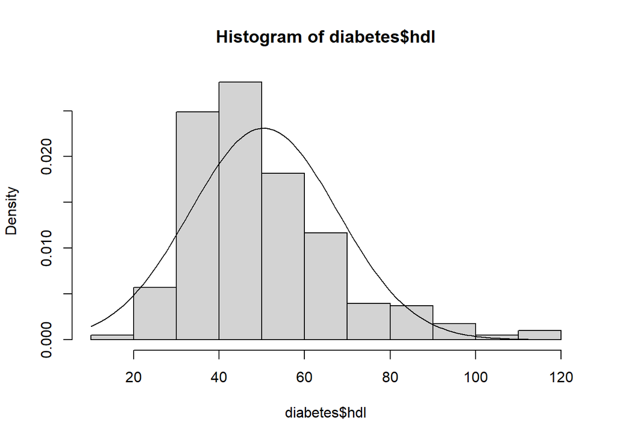

```r
data(diabetes)
#View(diabetes)
hist(diabetes$hdl,freq=FALSE)
curve(dnorm(x,mean(diabetes$hdl,na.rm=TRUE),sd(diabetes$hdl,na.rm=TRUE)), add=TRUE)
```

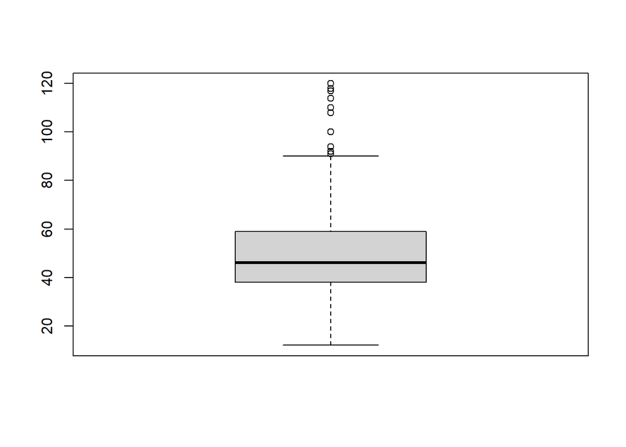

```r
boxplot(diabetes$hdl)
```

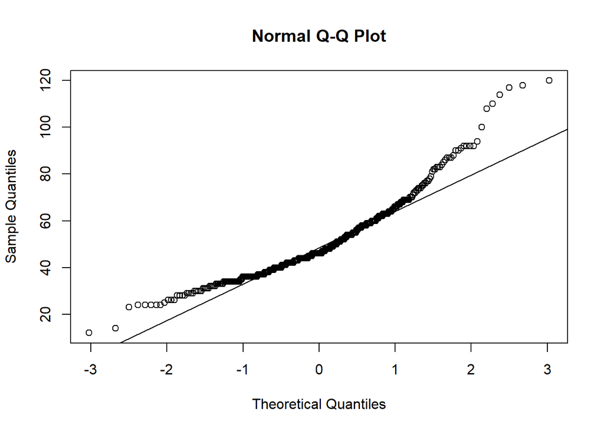

```r
qqnorm(diabetes$hdl)
qqline(diabetes$hdl)
```

### Respostas - Questão 7

```r
shapiro.test(diabetes$hdl)
```

```
##
##  Shapiro-Wilk normality test
##
## data:  diabetes$hdl
## W = 0.92357, p-value = 1.918e-13
```